# Week 8 Problem

Mina Mehdinia

2022-05-22

Let’s use the got_chars data set in the repurrrsive package

```r
library(datasets)
library(repurrrsive)
library(purrr)
class(got_chars)
```

```
## [1] "list"
```

1)Using the appropriate map function extract the name of all characters in GOT

```r
map_chr(got_chars, "name")
```

```
##  [1] "Theon Greyjoy"      "Tyrion Lannister"   "Victarion Greyjoy"
##  [4] "Will"               "Areo Hotah"         "Chett"
##  [7] "Cressen"            "Arianne Martell"    "Daenerys Targaryen"
## [10] "Davos Seaworth"     "Arya Stark"         "Arys Oakheart"
## [13] "Asha Greyjoy"       "Barristan Selmy"    "Varamyr"
## [16] "Brandon Stark"      "Brienne of Tarth"   "Catelyn Stark"
## [19] "Cersei Lannister"   "Eddard Stark"       "Jaime Lannister"
## [22] "Jon Connington"     "Jon Snow"           "Aeron Greyjoy"
## [25] "Kevan Lannister"    "Melisandre"         "Merrett Frey"
## [28] "Quentyn Martell"    "Samwell Tarly"      "Sansa Stark"
```

2.Use map to extract for all elements of the list the id, name and gender

```r
map(got_chars, `[`, c("id", "name", "gender"))
```

```
## [[1]]
## [[1]]$id
## [1] 1022
##
## [[1]]$name
## [1] "Theon Greyjoy"
##
## [[1]]$gender
## [1] "Male"
##
##
## [[2]]
## [[2]]$id
## [1] 1052
##
## [[2]]$name
## [1] "Tyrion Lannister"
##
## [[2]]$gender
## [1] "Male"
##
##
## [[3]]
## [[3]]$id
## [1] 1074
##
## [[3]]$name
## [1] "Victarion Greyjoy"
##
## [[3]]$gender
## [1] "Male"
##
##
## [[4]]
## [[4]]$id
## [1] 1109
##
## [[4]]$name
## [1] "Will"
##
```

[output cut: 273 more lines]

```
## [1] "Samwell Tarly"
##
## [[29]]$gender
## [1] "Male"
##
##
## [[30]]
## [[30]]$id
## [1] 957
##
## [[30]]$name
## [1] "Sansa Stark"
##
## [[30]]$gender
## [1] "Female"
```

3)Generate a tidy data frame (tibble) containing the variables name, culture, gender, id, born, alive for all characters.

```r
map_df(got_chars, `[`, c("name", "culture", "gender", "id", "born", "alive"))
```

```
## # A tibble: 30 x 6
##    name               culture    gender    id born                         alive
##    <chr>              <chr>      <chr>  <int> <chr>                        <lgl>
##  1 Theon Greyjoy      "Ironborn" Male    1022 "In 278 AC or 279 AC, at Py~ TRUE
##  2 Tyrion Lannister   ""         Male    1052 "In 273 AC, at Casterly Roc~ TRUE
##  3 Victarion Greyjoy  "Ironborn" Male    1074 "In 268 AC or before, at Py~ TRUE
##  4 Will               ""         Male    1109 ""                           FALSE
##  5 Areo Hotah         "Norvoshi" Male    1166 "In 257 AC or before, at No~ TRUE
##  6 Chett              ""         Male    1267 "At Hag's Mire"              FALSE
##  7 Cressen            ""         Male    1295 "In 219 AC or 220 AC"        FALSE
##  8 Arianne Martell    "Dornish"  Female   130 "In 276 AC, at Sunspear"     TRUE
##  9 Daenerys Targaryen "Valyrian" Female  1303 "In 284 AC, at Dragonstone"  TRUE
## 10 Davos Seaworth     "Westeros" Male    1319 "In 260 AC or before, at Ki~ TRUE
## # ... with 20 more rows
```

Implement arg_max().

Inputs: a function and a vector

Output: the elements of the input where the function returns the highest value.

For example: * arg_max(-10:5, function(x) x ^ 2) should return -10

```r
arg_max <- function(f,x){
  x[f(x) == max(f(x))]
}
arg_max(-10:10, f = function(x)x^2)
```

```
## [1] -10  10
```

```r
arg_max(-10:10, f = function(x)sin(x))
```

```
## [1] 8
```

```r
sin(-10:10)
```

```
##  [1]  0.5440211 -0.4121185 -0.9893582 -0.6569866  0.2794155  0.9589243
##  [7]  0.7568025 -0.1411200 -0.9092974 -0.8414710  0.0000000  0.8414710
## [13]  0.9092974  0.1411200 -0.7568025 -0.9589243 -0.2794155  0.6569866
## [19]  0.9893582  0.4121185 -0.5440211
```

Use reduce() to find all the elements that appear in at least one entry of the following list

```r
(my.list <- map(1:4, ~ sample(1:10, 15, replace = T)))
```

```
## [[1]]
##  [1]  8  3  4  5  8  9  8  7  4  6  7  1  5  5 10
##
## [[2]]
##  [1] 1 2 4 9 7 8 4 1 2 8 5 5 3 8 4
##
## [[3]]
##  [1] 10  6  5  2  4  5  8  9 10  7  5  7  9 10 10
##
## [[4]]
##  [1]  1  3  6  5 10  9  5  4  7  4  3 10  2  3 10
```

```r
reduce(my.list, union)
```

```
##  [1]  8  3  4  5  9  7  6  1 10  2
```

```r
accumulate(my.list, union)
```

```
## [[1]]
##  [1]  8  3  4  5  8  9  8  7  4  6  7  1  5  5 10
##
## [[2]]
##  [1]  8  3  4  5  9  7  6  1 10  2
##
## [[3]]
##  [1]  8  3  4  5  9  7  6  1 10  2
##
## [[4]]
##  [1]  8  3  4  5  9  7  6  1 10  2
```

Rewrite this function as a function factory:

```r
boxcox1 <- function(x, lambda) {
  stopifnot(length(lambda) == 1)

  if (lambda == 0) {
    log(x)
  } else {
    (x ^ lambda - 1) / lambda
  }
}
```

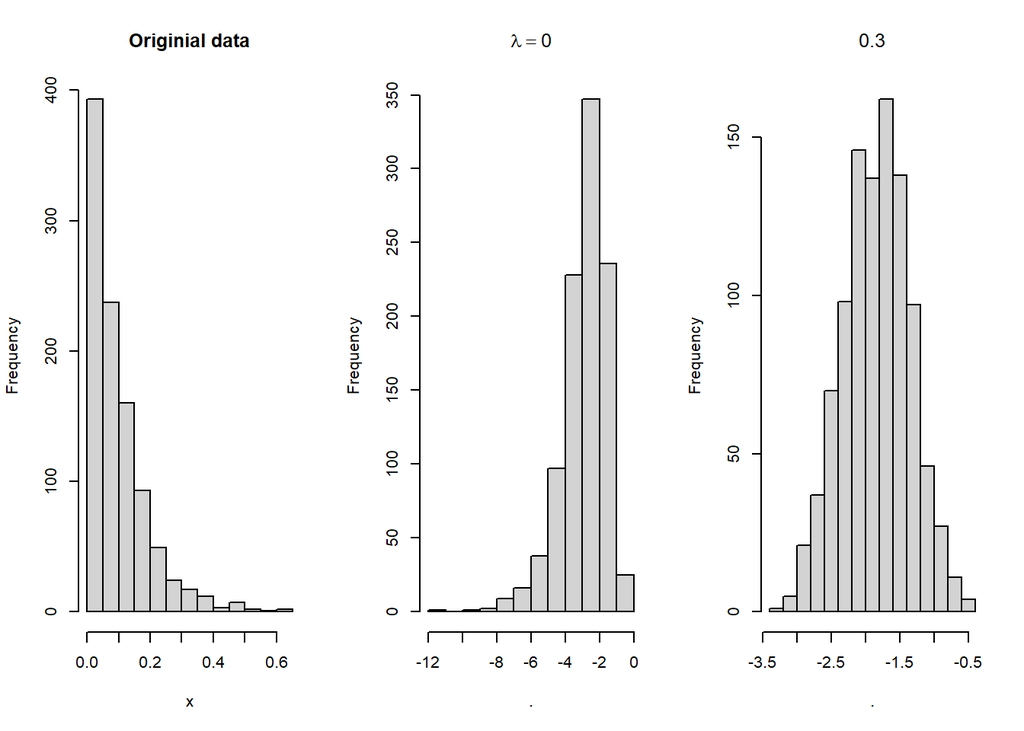

```r
bc.factlambda <- function(lambda){
  stopifnot(length(lambda)== 1)
  force(lambda)
  if(lambda == 0){
    function(x){
      log(x)
    }
  }else{
    function(x){
      (x ^ lambda - 1) / lambda
    }
  }
}

bc.0 <- bc.factlambda(lambda = 0)
bc.other <- bc.factlambda(lambda = 0.3)

x <- rgamma(1000,1,10)

par(mfrow = c(1,3))
hist(x, main = "Originial data")
bc.0(x) %>% hist(main = expression(lambda ==0))
bc.other(x) %>% hist(main = expression(lambda = 0.3))
```

Recall the sleep vs caffeine experiment? Write the function factory my.perm.test, which takes:

1. a data.frame,
2. the name of the variable with the group labels (assume there are only two groups), and

3)the name of the variable with the values, and returns the difference between the means of the permuted groups

Use this function to generate 10,000 draws of the permuted differences for the sleep vs caffeine data found here:

```r
Memory <- read.csv("http://www.mosaic-web.org/go/datasets/SleepCaffeine.csv")
```

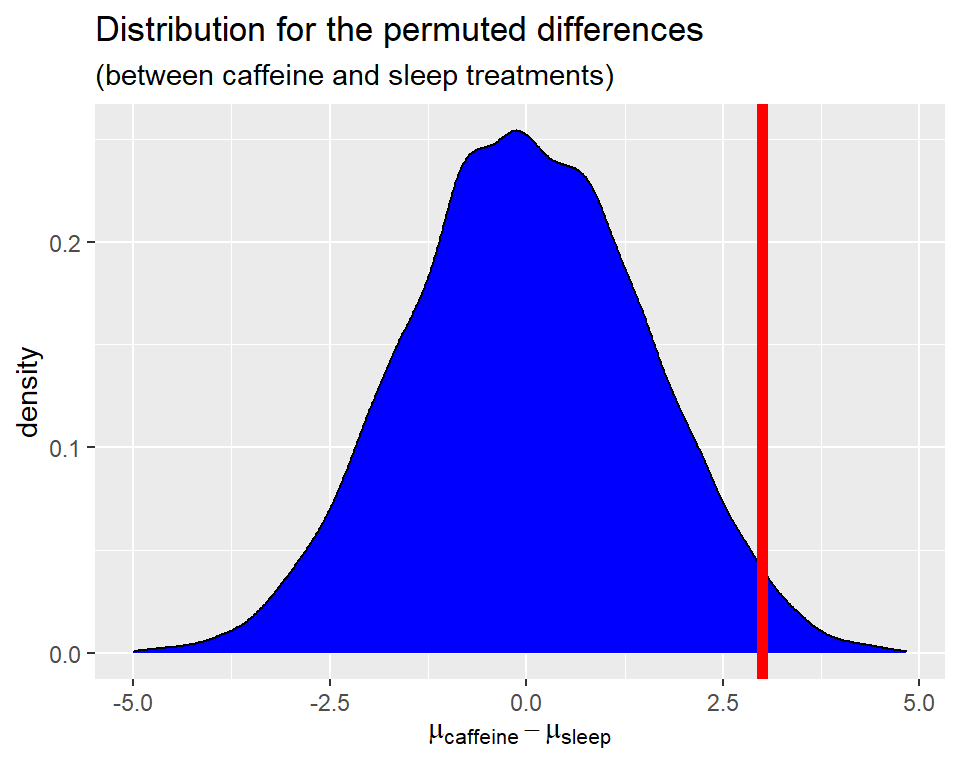

```r
library(purrr)
library(stringr)
library(ggplot2)
library(tidyverse)
my_perm_wrap <- function(df, label.var, value.var) {
  function() {
    vv <- sample(1:nrow(df), replace = F)
    perm_labels <- df[[label.var]][vv]
    by(df[[value.var]], perm_labels, mean) %>% diff()
  }
}

my_perm_test <- my_perm_wrap(Memory, label.var = "Group", value.var = "Words")

vec_of_perm_diffs <- map_dbl(1:10000, ~ my_perm_test())

tibble(differ = vec_of_perm_diffs) %>%
  ggplot(aes(x = differ)) +
  geom_density(fill = "blue") +
  geom_vline(xintercept = (with(Memory, by(Words, Group, mean)) %>%  diff()),
             color = "red", lwd = 2) +
  xlab(expression(mu[caffeine] - mu[sleep])) +
  labs(title = "Distribution for the permuted differences",
       subtitle = "(between caffeine and sleep treatments)")
```